# Portfolio 4

AwesomePie1453

3/11/2022

### Welcome Back!

The last three portfolios, we have looked at the top four MVP Quarterbacks of the 2010 season, as well as their running backs and top receivers. Today, we will present the previous graphs in ways that will more aptly compare the teams.

### Quarterbacks

Here we have Aaron Rodgers, Tom Brady, Phillip Rivers and Michael Vick. The stats we used (slightly different than portfolio 1) are their weekly passing yards, their weekly passing touchdowns, their weekly intereceptions, and their weekly passer rating. This should give us a good idea of the passing stats of each QB each week.

```r
attach(nfl_QBs)
```

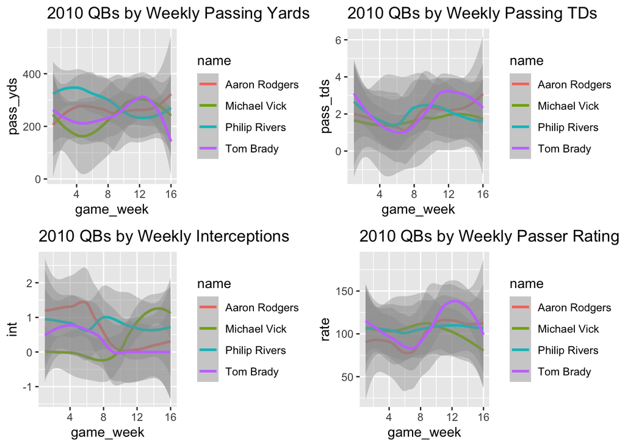

```r
grid.arrange(Passing_yards,Passing_tds,interceptions,passer_rating, ncol = 2)
```

### Running Backs

Next, lets look at their Running Backs. We chose to look at their weekly rushing yards, yards per rush, fumbles, touches, total yards, and total touchdowns. A Running Back is a large part of an offense, so they require more stats for us to look at for comparison.

```r
attach(nfl_RBs)
```

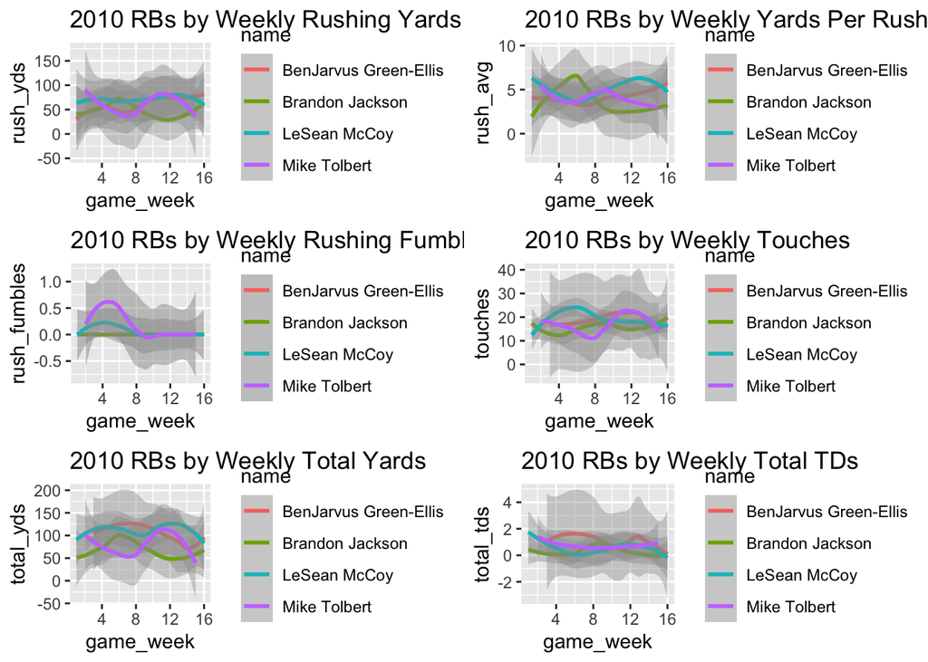

```r
grid.arrange(Rushing_yards, Rushing_average, Rushing_fumbles, Rushing_touches, Total_yards, Total_Tds, ncol = 2)
```

### Receivers

Lastly, here are the top two receivers (WR/TE) per team. For this we chose receiving yards, receptions, receiving touchdowns, and this time we also added rushing yards to look at another part of the receiver’s dynamic ability.

```r
attach(nfl_WR_combined)
```

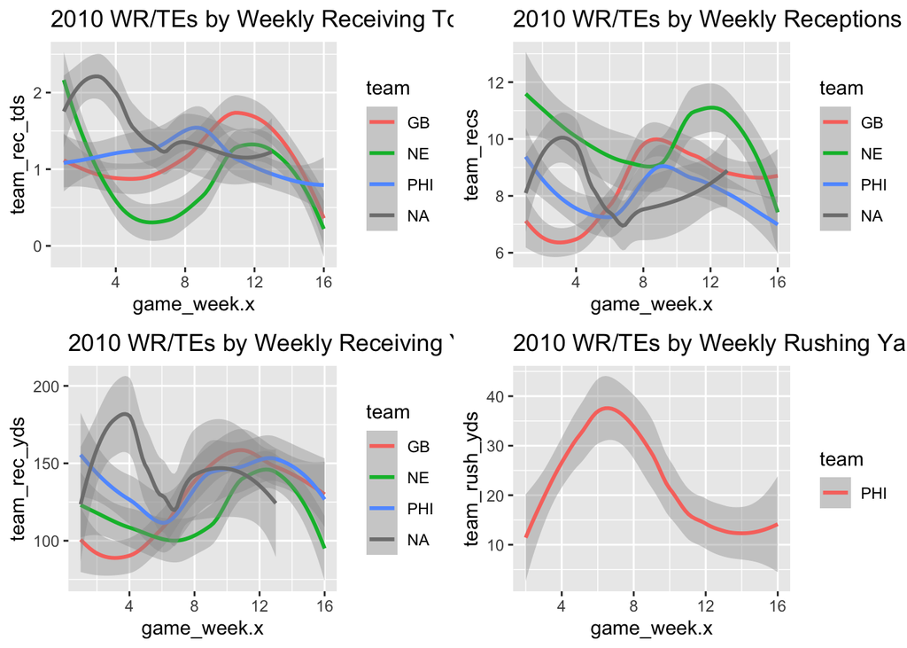

```r
grid.arrange(Receiving_TDs, Receptions, Receiving_yards, Rushing_yards_WR, ncol = 2)
```

### Conclusion

This 4th portfolio is a way to compare all of the stats together, instead of scrolling through multiple graphs. Some obselete stats were taken out from our graphs, and now we have a cleaner, udpated version of what we have been working on. Now, there still are some issues. Anf hopefully in the future we will be able to fix them! See you next time :)